# Behavioral Analysis Posner+SSVEP paradigm

[Christopher Gundlach](https://www.researchgate.net/profile/Christopher_Gundlach)

2024-03-07

# Initialisierung

**Setting up R libraries**

# Analysis of Behavioral Data (Posner Paradigma)

## subaveraged Daten werden geladen

Loading data C:/Users/psy05cvd/Dropbox/work/R-statistics/experiments/ssvep_posnalpha_behave/data_in/Behavior_singletrials.txt

The data has the following structure

- trialnumber = trial
- blocknumber
- trial_timing_type = 1=regular; 2=control
- cue_validity = 1=valid, 2=invalid, 3=neutral
- cue_validity_label
- cue_direction = 1=left, 2=right
- cue_direction_label
- cue_onset_fr = frame number of cue presentation
- cue_onset_t_est = onset time in ms
- cue_onset_t_meas = nan
- pre_event_type = 1=shorter, 2=longer, NaN=no event
- pre_event_onset_fr = onset frame of event
- pre_event_onset_t_est = onset time in ms
- pre_event_onset_t_meas = nan
- post_event_pos = position of post event: 1 = left, 2=right
- post_event_pos_label
- post_event_direction = direction of target (-90:90)=top;
- post_event_direction_c = category of target position: 1=top; 2=bottom
- post_event_direction_c_l = label
- post_event_dimenstion = size in degrees
- post_event_onset_fr = onset frames of event
- post_event_onset_t_est = onset times of events
- post_event_onset_t_meas = nan
- triggernum = trigger number
- pre_hit = empty=no event, TRUE=hit, 0=error, NaN=miss
- pre_RT = RT in ms
- post_hit = TRUE=hit, 0=error, NaN=miss
- post_RT = RT in ms
- subject

# Illustration of Data of pre-cue task

1a Illustrate Data as is

```r
# unique(DATA.In_long$pre_hit)

DATA.In_long %>%
  #filter(trial_timing_type == 1) %>%
  dplyr::select(subject, trialnumber, pre_event_type, pre_hit, pre_RT) %>%
  filter(pre_event_type!="NaN")%>%
  mutate(pre_hit = case_when(pre_hit == "NaN" ~ 'miss',
                             pre_hit == 1 ~ 'hit',
                             pre_hit == 0 ~ 'error'
                             )) %>%
  group_by(subject, pre_hit) %>%
  summarise(n_resp= n(), mean_RT = mean(pre_RT, na.rm=TRUE)) %>%
  ungroup()%>%
  complete(subject, pre_hit, fill= list(n_resp = 0, mean_RT = NaN))%>%
  group_by(subject)%>%
  mutate(n_targs = sum(n_resp), rate_perc = (n_resp/n_targs)*100)%>%
  ungroup()%>%
  group_by(pre_hit)%>%
  summarise(M_reaction_time = mean(mean_RT), SD_reaction_time = sd(mean_RT),
            M_response_rate = mean(rate_perc), SD_response_rate = sd(rate_perc))%>%
  kable(escape = F, digits = c(3,3,3,6,3,3,3,3,3), caption = c("average pre_cue response measures")) %>%
  kable_styling("striped", full_width = T, bootstrap_options = c("striped", "hover", "condensed", "responsive",font_size = 8))
```

[output not shown]

# Illustration of Data of Main experiment/post-cue task

1a Illustrate Data as is

- separate for left and right target

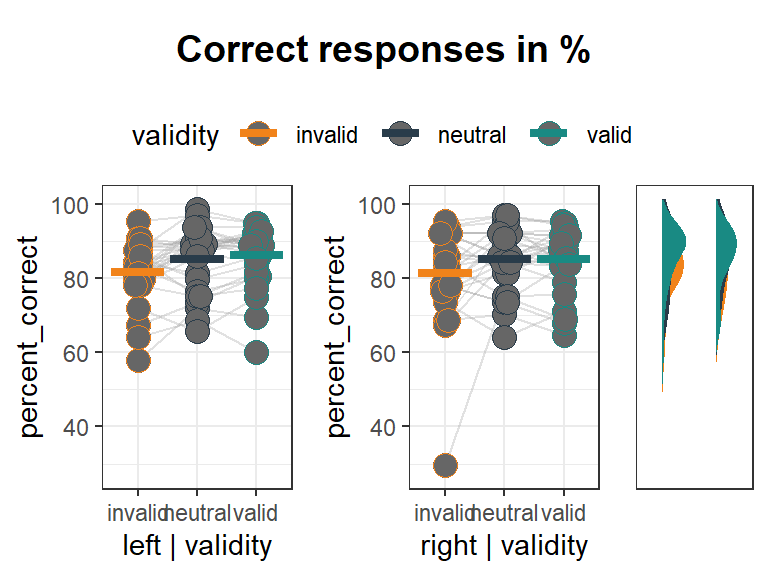

```r
dat_plot <- DATA.In_long %>%
  filter(trial_timing_type == 1) %>%
  dplyr::select(subject, trialnumber, cue_validity_label, post_event_pos_label, post_hit, post_RT) %>%
  group_by(subject, cue_validity_label, post_event_pos_label, post_hit) %>%
  summarise(n_resp= n(), mean_RT = mean(post_RT)) %>%
  ungroup()%>%
  group_by(subject, cue_validity_label, post_event_pos_label) %>%
  mutate(n_cons = sum(n_resp), rate_perc = (n_resp/n_cons)*100) %>%
  mutate(post_hit = ifelse(post_hit=="NaN","miss",ifelse(post_hit=="0","error","hit")))%>%
  filter(post_hit == "hit")%>%
  select(subject,validity=cue_validity_label,side=post_event_pos_label, post_hit, mean_RT, percent_correct = rate_perc, n_resp, n_cons)
  # filter(post_hit == "error")
#mutate(time=factor(time, levels = c('pre', 'post'), ordered = T))

## percent correct
#find ylims
temp_ylims <- dat_plot%>%
  ungroup()%>%
  summarise(
    min = min(percent_correct) - (max(percent_correct)-min(percent_correct))*.04,
    max = max(percent_correct)+ (max(percent_correct)-min(percent_correct))*.04)


dat2plot <- dat_plot %>%
  filter(side=='left')


theme_set(theme_bw())
plot1 <- ggplot(dat2plot, aes(x=validity, y=percent_correct, fill=validity, color = validity)) +
  geom_line(aes(group = subject),alpha = 0.3, colour = "grey60") +
  geom_beeswarm(cex=1.5, size = 4, shape=21,alpha=1,fill="grey40",shape=21)+
  stat_summary(fun=mean, aes(ymin=..y.., ymax=..y.., color =validity), geom='errorbar', width=0.9, size=1.5) +
  # stat_summary(fun.data=mean_se, geom="errorbar", width=0.5,lwd=1)+
    # geom_boxplot(width=0.4, fill="white", alpha=0, lwd=1, color="grey60")+
  theme(legend.position="none")+
  # theme(legend.position="bottom")+
  scale_color_manual(values=c("#F1831A", "#293C4A", "#198A83"))+
  scale_fill_manual(values=c("#F1831A", "#293C4A", "#198A83"))+
  scale_y_continuous(limits=c(temp_ylims$min, temp_ylims$max))+
  xlab('left | validity')

dat2plot <- dat_plot %>%
  filter(side=='right')

plot2 <- ggplot(dat2plot, aes(x=validity, y=percent_correct, fill=validity, color = validity)) +
  geom_line(aes(group = subject),alpha = 0.3, colour = "grey60") +
  geom_beeswarm(cex=1.5, size = 4, shape=21,alpha=1,fill="grey40",shape=21)+
  stat_summary(fun=mean, aes(ymin=..y.., ymax=..y.., color =validity), geom='errorbar', width=0.9, size=1.5) +
  # stat_summary(fun.data=mean_se, geom="errorbar", width=0.5,lwd=1)+
    # geom_boxplot(width=0.4, fill="white", alpha=0, lwd=1, color="grey60")+
  theme(legend.position="none")+
  # theme(legend.position="bottom")+
  scale_color_manual(values=c("#F1831A", "#293C4A", "#198A83"))+
  scale_fill_manual(values=c("#F1831A", "#293C4A", "#198A83"))+
  scale_y_continuous(limits=c(temp_ylims$min, temp_ylims$max))+
  xlab('right | validity')


plot3 <- ggplot(dat_plot, aes(y = percent_correct, fill = validity, x = 1)) +
  geom_flat_violin(aes(x = side, fill = validity),
                   position = position_nudge(x = -.1, y = 0),
                   adjust = 1.3, trim = FALSE, alpha = 1, colour = NA)+
  # geom_hline(yintercept=0, show.legend = FALSE) +
  scale_color_manual(values=c("#F1831A", "#293C4A", "#198A83"))+
  scale_fill_manual(values=c("#F1831A", "#293C4A", "#198A83"))+
  theme(axis.title.y=element_blank(),
        axis.text.y=element_blank(),
        axis.ticks.y=element_blank())+
  theme(axis.title.x=element_blank(),
        axis.text.x=element_blank(),
        axis.ticks.x=element_blank())+
  theme(panel.grid.major = element_blank(), panel.grid.minor = element_blank())+
  # scale_y_continuous(limits=c(-60, 140))
  theme(legend.position="none")+
  scale_y_continuous(limits=c(temp_ylims$min, temp_ylims$max))



# cowplot::plot_grid(plot1, plot2, plot3, ncol = 3,labels = "AUTO")
plotttitle <- ggdraw() + draw_label("Correct responses in %", fontface='bold')
plotplots <- ggarrange(plot1, plot2, plot3, ncol = 3,common.legend = TRUE,align = "h", widths=c(2,2,1))
ggarrange(plotttitle, plotplots, nrow = 2, heights=c(0.2, 1))
```

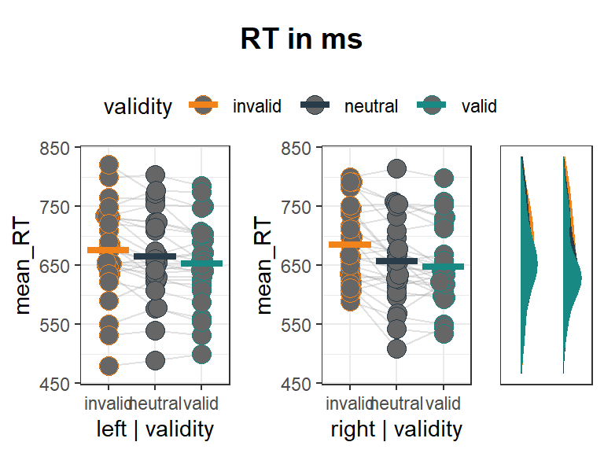

```r
## RT
#find ylims
temp_ylims <- dat_plot%>%
  ungroup()%>%
  summarise(
    min = min(mean_RT) - (max(mean_RT)-min(mean_RT))*.04,
    max = max(mean_RT)+ (max(mean_RT)-min(mean_RT))*.04)


dat2plot <- dat_plot %>%
  filter(side=='left')


theme_set(theme_bw())
plot1 <- ggplot(dat2plot, aes(x=validity, y=mean_RT, fill=validity, color = validity)) +
  geom_line(aes(group = subject),alpha = 0.3, colour = "grey60") +
  geom_beeswarm(cex=1.5, size = 4, shape=21,alpha=1,fill="grey40",shape=21)+
  stat_summary(fun=mean, aes(ymin=..y.., ymax=..y.., color =validity), geom='errorbar', width=0.9, size=1.5) +
  # stat_summary(fun.data=mean_se, geom="errorbar", width=0.5,lwd=1)+
    # geom_boxplot(width=0.4, fill="white", alpha=0, lwd=1, color="grey60")+
  theme(legend.position="none")+
  # theme(legend.position="bottom")+
  scale_color_manual(values=c("#F1831A", "#293C4A", "#198A83"))+
  scale_fill_manual(values=c("#F1831A", "#293C4A", "#198A83"))+
  scale_y_continuous(limits=c(temp_ylims$min, temp_ylims$max))+
  xlab('left | validity')

dat2plot <- dat_plot %>%
  filter(side=='right')

plot2 <- ggplot(dat2plot, aes(x=validity, y=mean_RT, fill=validity, color = validity)) +
  geom_line(aes(group = subject),alpha = 0.3, colour = "grey60") +
  geom_beeswarm(cex=1.5, size = 4, shape=21,alpha=1,fill="grey40",shape=21)+
  stat_summary(fun=mean, aes(ymin=..y.., ymax=..y.., color =validity), geom='errorbar', width=0.9, size=1.5) +
  # stat_summary(fun.data=mean_se, geom="errorbar", width=0.5,lwd=1)+
    # geom_boxplot(width=0.4, fill="white", alpha=0, lwd=1, color="grey60")+
  theme(legend.position="none")+
  # theme(legend.position="bottom")+
  scale_color_manual(values=c("#F1831A", "#293C4A", "#198A83"))+
  scale_fill_manual(values=c("#F1831A", "#293C4A", "#198A83"))+
  scale_y_continuous(limits=c(temp_ylims$min, temp_ylims$max))+
  xlab('right | validity')


plot3 <- ggplot(dat_plot, aes(y = mean_RT, fill = validity, x = 1)) +
  geom_flat_violin(aes(x = side, fill = validity),
                   position = position_nudge(x = -.1, y = 0),
                   adjust = 1.3, trim = FALSE, alpha = 1, colour = NA)+
  # geom_hline(yintercept=0, show.legend = FALSE) +
  scale_color_manual(values=c("#F1831A", "#293C4A", "#198A83"))+
  scale_fill_manual(values=c("#F1831A", "#293C4A", "#198A83"))+
  theme(axis.title.y=element_blank(),
        axis.text.y=element_blank(),
        axis.ticks.y=element_blank())+
  theme(axis.title.x=element_blank(),
        axis.text.x=element_blank(),
        axis.ticks.x=element_blank())+
  theme(panel.grid.major = element_blank(), panel.grid.minor = element_blank())+
  # scale_y_continuous(limits=c(-60, 140))
  theme(legend.position="none")+
  scale_y_continuous(limits=c(temp_ylims$min, temp_ylims$max))



# cowplot::plot_grid(plot1, plot2, plot3, ncol = 3,labels = "AUTO")
plotttitle <- ggdraw() + draw_label("RT in ms", fontface='bold')
plotplots <- ggarrange(plot1, plot2, plot3, ncol = 3,common.legend = TRUE,align = "h", widths=c(2,2,1))
ggarrange(plotttitle, plotplots, nrow = 2, heights=c(0.2, 1))
```

histogram

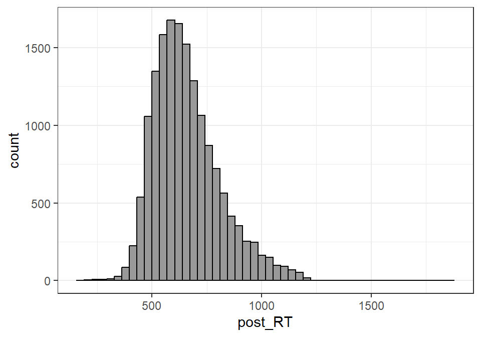

```r
dat_plot <- DATA.In_long %>%
  filter(trial_timing_type == 1) %>%
  dplyr::select(subject, trialnumber, cue_validity_label, post_event_pos_label, post_hit, post_RT)

mu <- dat_plot %>%
  group_by(subject, cue_validity_label)%>%
  summarize(RT = mean(post_RT,na.rm = TRUE))%>%
  ungroup()%>%
  group_by(cue_validity_label)%>%
  summarize(grp.mean = mean(RT,na.rm = TRUE), grp.median = median(RT,na.rm = TRUE))
theme_set(theme_bw())
ggplot(dat_plot, aes(x=post_RT)) +
  geom_histogram(color="black", fill="grey60", bins = 50)
```

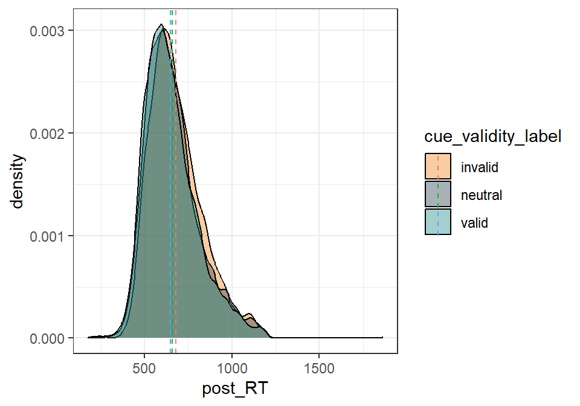

```r
ggplot(dat_plot, aes(x=post_RT,fill= cue_validity_label)) +
  # geom_histogram(color="black",position="dodge")+
  # geom_histogram(color="black",position="identity", alpha=0.3, bins = 50)+
  geom_density(alpha=0.4, lwd=0.5, adjust=0.8)+
  # geom_vline(data=mu, aes(xintercept=grp.mean, color=cue_validity_label),
  #            linetype="dashed")+
  geom_vline(data=mu, aes(xintercept=grp.median, color=cue_validity_label),
             linetype="dashed")+
  scale_fill_manual(values=c("#F1831A", "#293C4A", "#198A83"))
```

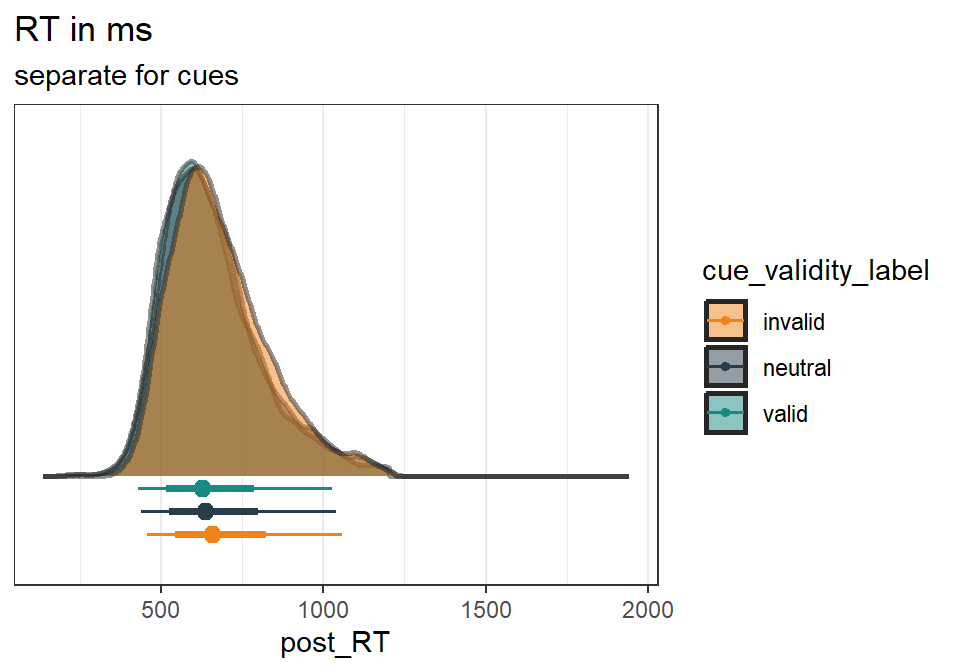

```r
ggplot(dat_plot, aes(fill = cue_validity_label, color = cue_validity_label, x = post_RT)) +
  stat_slab(alpha = 0.5, color = "gray15",
            expand = TRUE, trim = FALSE,    fill_type = "segments") +
  stat_pointinterval(position = position_dodge(width = .4, preserve = "single")) +
  labs(
    title = "RT in ms",
    subtitle = "separate for cues",
    y = NULL
  ) +
  scale_y_continuous(breaks = NULL)+
  scale_fill_manual(values=c("#F1831A", "#293C4A", "#198A83"))+
  scale_color_manual(values=c("#F1831A", "#293C4A", "#198A83"))
```

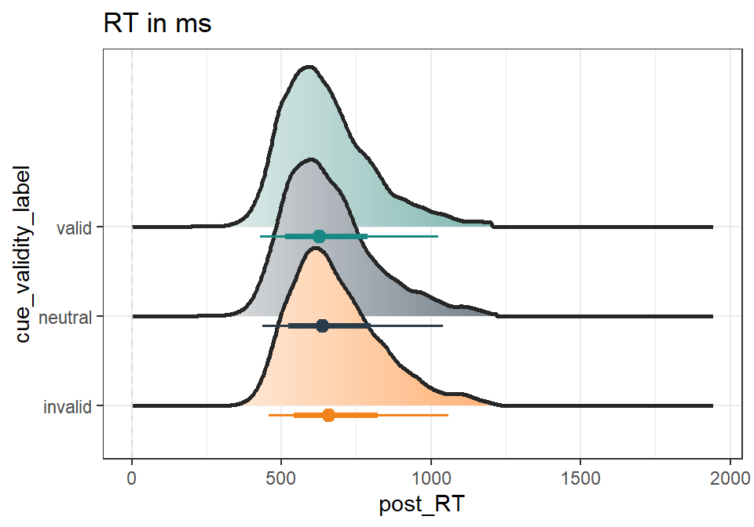

```r
ggplot(dat_plot, aes(
    y = cue_validity_label, x = post_RT,
    fill = cue_validity_label, fill_ramp = after_stat(abs(x)),
    color_ramp = after_stat(-dnorm(x, 0, 2))
  )) +
  stat_slab(
    height = 2, color = "gray15",
    expand = TRUE, trim = FALSE,
    fill_type = "segments",
    show.legend = FALSE
  ) +
  geom_vline(xintercept = 0, color = "gray85", linetype = "dashed") +
  ggtitle(
    'RT in ms',
  ) +
  stat_pointinterval(position = position_dodge(width = .4, preserve = "single"), show.legend = FALSE,
                     aes(color=cue_validity_label)) +
  scale_fill_manual(values=c("#F1831A", "#293C4A", "#198A83")) +
  scale_color_manual(values=c("#F1831A", "#293C4A", "#198A83"))
```

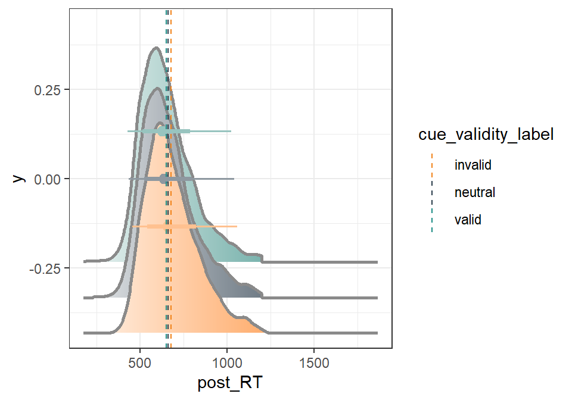

```r
ggplot(dat_plot, aes(
    x = post_RT,
    fill = cue_validity_label, fill_ramp = after_stat(abs(x)),
    color_ramp = after_stat(-dnorm(x, 0, 2))
  )) +
  stat_slab(
    height = 2, color = "gray15",
    expand = TRUE, trim = TRUE,
    fill_type = "segments",
    show.legend = FALSE,
    position = position_dodgejust(0.3)
  ) +
  stat_pointinterval(position = position_dodgejust(width = .4, preserve = "single", justification = 2),
                     show.legend = FALSE,
                     aes(color=cue_validity_label)) +
  geom_vline(data=mu, aes(xintercept=grp.median, color=cue_validity_label),
             linetype="dashed")+
  scale_fill_manual(values=c("#F1831A", "#293C4A", "#198A83")) +
  scale_color_manual(values=c("#F1831A", "#293C4A", "#198A83"))
```

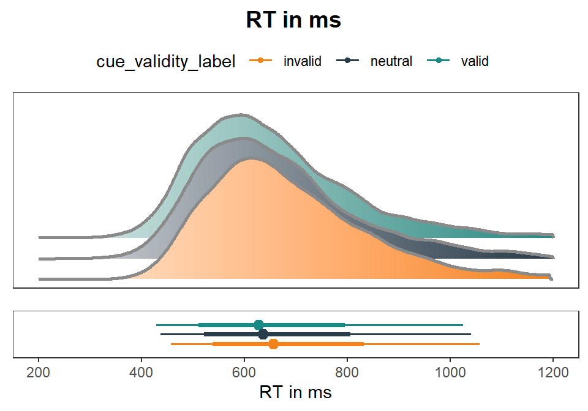

```r
plot1 <-
  ggplot(dat_plot, aes(
    x = post_RT,
    fill = cue_validity_label, fill_ramp = after_stat(abs(x)),
    color_ramp = after_stat(-dnorm(x, 0, 2))
  )) +
  stat_slab(
    height = 2, color = "gray15",
    expand = TRUE, trim = TRUE,
    fill_type = "segments",
    show.legend = FALSE,
    position = position_dodgejust(0.3),
  )+
  theme(axis.text.y=element_blank(),axis.ticks.y=element_blank(), axis.title.y = element_blank())+
  theme(axis.text.x=element_blank(),axis.ticks.x=element_blank(), axis.title.x = element_blank())+
  theme(panel.grid.major = element_blank(), panel.grid.minor = element_blank())+
  scale_fill_manual(values=c("#F1831A", "#293C4A", "#198A83")) +
  scale_color_manual(values=c("#F1831A", "#293C4A", "#198A83"))+
  xlim(c(200, 1200))

plot2 <-
  ggplot(dat_plot, aes(
    x = post_RT,
    fill = cue_validity_label
  )) +
  stat_pointinterval(position = position_dodge(width = .4, preserve = "single"),
                     aes(color=cue_validity_label), .width= c(.68, .95)) +
  theme(axis.text.y=element_blank(),axis.ticks.y=element_blank(), axis.title.y = element_blank())+
  theme(panel.grid.major = element_blank(), panel.grid.minor = element_blank())+
  scale_x_continuous(name="RT in ms", breaks=c(200,400,600,800,1000,1200), labels=waiver(), limits=c(200,1200))+
  scale_fill_manual(values=c("#F1831A", "#293C4A", "#198A83")) +
  scale_color_manual(values=c("#F1831A", "#293C4A", "#198A83"))



# cowplot::plot_grid(plot1, plot2, plot3, ncol = 3,labels = "AUTO")
plotttitle <- ggdraw() + draw_label("RT in ms", fontface='bold')
plotplots <- ggarrange(plot1, plot2, nrow = 2, align = "v", heights =c(4,2), common.legend = TRUE)
g<-ggarrange(plotttitle, plotplots, nrow = 2, heights=c(0.1, 1))

# print(g)
ggsave(filename = "figures/RT_distribution_validityeffects.eps", width = 5, height = 3.5,
       plot = print(g))
```

1b Illustrate Data as is

- averaged across left and right targets

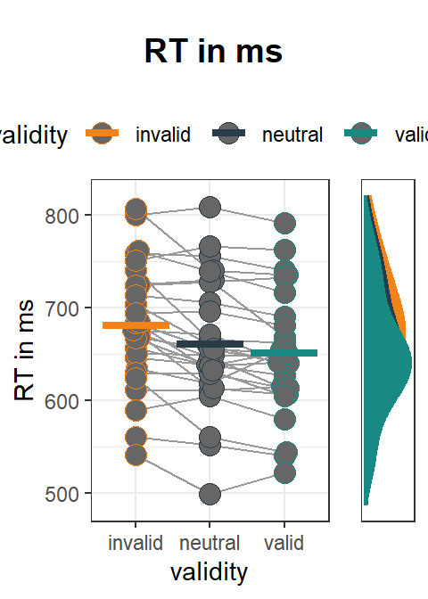

```r
dat_plot <- DATA.In_long %>%
  filter(trial_timing_type == 1) %>%
  dplyr::select(subject, trialnumber, cue_validity_label, post_event_pos_label, post_hit, post_RT) %>%
  group_by(subject, cue_validity_label, post_event_pos_label, post_hit) %>%
  summarise(n_resp= n(), mean_RT = mean(post_RT)) %>%
  ungroup()%>%
  group_by(subject, cue_validity_label, post_hit) %>%
  summarise(n_resp= sum(n_resp), mean_RT = mean(mean_RT)) %>%
  ungroup()%>%
  group_by(subject, cue_validity_label) %>%
  mutate(n_cons = sum(n_resp), rate_perc = (n_resp/n_cons)*100) %>%
  mutate(post_hit = ifelse(post_hit=="NaN","miss",ifelse(post_hit=="0","error","hit")))%>%
  filter(post_hit == "hit")%>%
  select(subject,validity=cue_validity_label, post_hit, mean_RT, rate_perc, n_resp, n_cons)
## RT in ms
#find ylims
temp_ylims <- dat_plot%>%
  ungroup()%>%
  summarise(
    min = min(mean_RT) - (max(mean_RT)-min(mean_RT))*.04,
    max = max(mean_RT)+ (max(mean_RT)-min(mean_RT))*.04)


theme_set(theme_bw())
plot1 <- ggplot(dat_plot, aes(x=validity, y=mean_RT, fill=validity, color = validity)) +
  geom_line(aes(group = subject),alpha = 1, colour = "grey60") +
  geom_beeswarm(cex=1.5, size = 4, shape=21,alpha=1,fill="grey40",shape=21)+
  stat_summary(fun=mean, aes(ymin=..y.., ymax=..y.., color =validity), geom='errorbar', width=0.9, size=1.5) +
  # stat_summary(fun.data=mean_se, geom="errorbar", width=0.5,lwd=1)+
    # geom_boxplot(width=0.4, fill="white", alpha=0, lwd=1, color="grey60")+
  theme(legend.position="none")+
  # theme(legend.position="bottom")+
  scale_color_manual(values=c("#F1831A", "#293C4A", "#198A83"))+
  scale_fill_manual(values=c("#F1831A", "#293C4A", "#198A83"))+
  scale_y_continuous(limits=c(temp_ylims$min, temp_ylims$max))+
  ylab('RT in ms')


plot2 <- ggplot(dat_plot, aes(y = mean_RT, fill = validity, x = 1)) +
  geom_flat_violin(aes(fill = validity),
                   position = position_nudge(x = -.1, y = 0),
                   adjust = 1.3, trim = FALSE, alpha = 1, colour = NA)+
  # geom_hline(yintercept=0, show.legend = FALSE) +
  scale_color_manual(values=c("#F1831A", "#293C4A", "#198A83"))+
  scale_fill_manual(values=c("#F1831A", "#293C4A", "#198A83"))+
  theme(axis.title.y=element_blank(),
        axis.text.y=element_blank(),
        axis.ticks.y=element_blank())+
  theme(axis.title.x=element_blank(),
        axis.text.x=element_blank(),
        axis.ticks.x=element_blank())+
  theme(panel.grid.major = element_blank(), panel.grid.minor = element_blank())+
  theme(legend.position="none")+
  scale_y_continuous(limits=c(temp_ylims$min, temp_ylims$max))



# cowplot::plot_grid(plot1, plot2, plot3, ncol = 3,labels = "AUTO")
plotttitle <- ggdraw() + draw_label("RT in ms", fontface='bold')
plotplots <- ggarrange(plot1, plot2, ncol = 2,common.legend = TRUE,align = "h", widths=c(4,1))
g<-ggarrange(plotttitle, plotplots, nrow = 2, heights=c(0.2, 1))

# print(g)
ggsave(filename = "figures/RT_validityeffects.eps", width = 2.5, height = 3.5,
       plot = print(g))
```

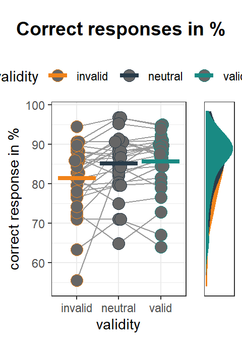

```r
## correct response in %
#find ylims
temp_ylims <- dat_plot%>%
  ungroup()%>%
  summarise(
    min = min(rate_perc) - (max(rate_perc)-min(rate_perc))*.04,
    max = max(rate_perc) + (max(rate_perc)-min(rate_perc))*.04)

theme_set(theme_bw())
plot1 <- ggplot(dat_plot, aes(x=validity, y=rate_perc, fill=validity, color = validity)) +
  geom_line(aes(group = subject),alpha = 1, colour = "grey60") +
  geom_beeswarm(cex=1.5, size = 4, shape=21,alpha=1,fill="grey40",shape=21)+
  stat_summary(fun=mean, aes(ymin=..y.., ymax=..y.., color =validity), geom='errorbar', width=0.9, size=1.5) +
  # stat_summary(fun.data=mean_se, geom="errorbar", width=0.5,lwd=1)+
    # geom_boxplot(width=0.4, fill="white", alpha=0, lwd=1, color="grey60")+
  theme(legend.position="none")+
  # theme(legend.position="bottom")+
  scale_color_manual(values=c("#F1831A", "#293C4A", "#198A83"))+
  scale_fill_manual(values=c("#F1831A", "#293C4A", "#198A83"))+
  scale_y_continuous(limits=c(temp_ylims$min, temp_ylims$max))+
  ylab('correct response in %')


plot2 <- ggplot(dat_plot, aes(y = rate_perc, fill = validity, x = 1)) +
  geom_flat_violin(aes(fill = validity),
                   position = position_nudge(x = -.1, y = 0),
                   adjust = 1.3, trim = FALSE, alpha = 1, colour = NA)+
  # geom_hline(yintercept=0, show.legend = FALSE) +
  scale_color_manual(values=c("#F1831A", "#293C4A", "#198A83"))+
  scale_fill_manual(values=c("#F1831A", "#293C4A", "#198A83"))+
  theme(axis.title.y=element_blank(),
        axis.text.y=element_blank(),
        axis.ticks.y=element_blank())+
  theme(axis.title.x=element_blank(),
        axis.text.x=element_blank(),
        axis.ticks.x=element_blank())+
  theme(panel.grid.major = element_blank(), panel.grid.minor = element_blank())+
  theme(legend.position="none")+
  scale_y_continuous(limits=c(temp_ylims$min, temp_ylims$max))



# cowplot::plot_grid(plot1, plot2, plot3, ncol = 3,labels = "AUTO")
plotttitle <- ggdraw() + draw_label("Correct responses in %", fontface='bold')
plotplots <- ggarrange(plot1, plot2, ncol = 2,common.legend = TRUE,align = "h", widths=c(4,1))
g<-ggarrange(plotttitle, plotplots, nrow = 2, heights=c(0.2, 1))

# print(g)
ggsave(filename = "figures/CR_validityeffects.eps", width = 2.5, height = 3.5,
       plot = print(g))
```

## decriptive data

### behavioral measures

validity x side

average response measures

| validity | side | M_reaction_time | SD_reaction_time | M_response_rate | SD_response_rate |
| --- | --- | --- | --- | --- | --- |
| invalid | left | 675.743 | 77.2961 | 81.641 | 8.297 |
| invalid | right | 684.656 | 63.8139 | 81.250 | 13.094 |
| neutral | left | 664.328 | 73.1636 | 85.100 | 8.616 |
| neutral | right | 657.386 | 71.3435 | 85.212 | 8.510 |
| valid | left | 653.379 | 68.7225 | 86.128 | 8.027 |
| valid | right | 647.738 | 65.7248 | 85.188 | 8.521 |

validity

average response measures

| validity | M_reaction_time | SD_reaction_time | M_response_rate | SD_response_rate |
| --- | --- | --- | --- | --- |
| invalid | 680.199 | 70.373 | 81.4453 | 10.862 |
| neutral | 660.857 | 71.685 | 85.1562 | 8.485 |
| valid | 650.559 | 66.687 | 85.6579 | 8.216 |

grand mean average response measures

| M_RT_gm | SD_RT_gm | M_RR_gm | SD_RR_gm |
| --- | --- | --- | --- |
| 663.872 | 64.899 | 84.086 | 7.40797 |

averaged sd according to proper formula

| avg_sd |
| --- |
| 133.509 |

grand mean average response measures

| mean_mean_RT | mean_sd_RT |
| --- | --- |
| 657.843 | 133.218 |

side

average response measures

| side | M_reaction_time | SD_reaction_time | M_response_rate | SD_response_rate |
| --- | --- | --- | --- | --- |
| left | 664.483 | 72.839 | 84.2896 | 8.440 |
| right | 663.260 | 68.066 | 83.8833 | 10.318 |

## tests

test of general model

### ANOVA RT

ANOVA_RM for reaction time: VALIDTIY(invalid, neutral, valid) X SIDE (left, right)

```r
#ANOVAe
StatsOut <- DATA.In_long %>%
  filter(trial_timing_type == 1) %>%
  dplyr::select(subject, trialnumber, cue_validity_label, post_event_pos_label, post_hit, post_RT) %>%
  group_by(subject, cue_validity_label, post_event_pos_label, post_hit) %>%
  summarise(n_resp= n(), mean_RT = mean(post_RT)) %>%
  ungroup()%>%
  group_by(subject, cue_validity_label, post_event_pos_label) %>%
  mutate(n_cons = sum(n_resp), rate_perc = (n_resp/n_cons)*100) %>%
  mutate(post_hit = ifelse(post_hit=="NaN","miss",ifelse(post_hit=="0","error","hit")))%>%
  filter(post_hit == "hit")%>%
  select(subject,validity=cue_validity_label,side=post_event_pos_label, post_hit, mean_RT, rate_perc, n_resp, n_cons)%>%
  aov_ez(id="subject", dv = "mean_RT", data = ., within = c("validity","side"), include_aov = TRUE)
StatsOut%>%
  .$anova_table %>%
  mutate(factor = rownames(.))%>%
  mutate(
    `Pr(>F)` = cell_spec(ifelse(round(`Pr(>F)`,4)<.001,"< .001",round(`Pr(>F)`,4)),
                        color = ifelse(is.nan(`Pr(>F)`),"blue", ifelse(`Pr(>F)` < .05, "green", "red")),
                        bold = ifelse(is.nan(`Pr(>F)`),F, ifelse(`Pr(>F)` < .05, T,F)),
                        align = "center")
  ) %>%
  dplyr::select(factor, `num Df`, `den Df`, MSE, `F`, ges, `Pr(>F)`) %>%
  kable(escape = F, digits = c(3,3,3,3,3,3,3,3,3), caption = c("repeated measures ANOVA | dv = RT")) %>%
  kable_styling("striped", full_width = T, bootstrap_options = c("striped", "hover", "condensed", "responsive",font_size = 8))
```

repeated measures ANOVA | dv = RT

|  | factor | num Df | den Df | MSE | F | ges | Pr(>F) |
| --- | --- | --- | --- | --- | --- | --- | --- |
| validity | validity | 1.628 | 43.943 | 772.998 | 20.160 | 0.031 | < .001 |
| side | side | 1.000 | 27.000 | 2293.291 | 0.027 | 0.000 | 0.8697 |
| validity:side | validity:side | 1.596 | 43.099 | 444.351 | 3.059 | 0.003 | 0.068 |

### Post-hoc t-Tests RT

```r
# aggregate data

post_hocs.valXside <- emmeans(StatsOut$aov, c("validity","side"), contr = "pairwise",adjust = "holm") # adjust = holm
post_hocs.validity <- emmeans(StatsOut$aov, c("validity"), contr = "pairwise",adjust = "holm") # adjust = holm
post_hocs.side <- emmeans(StatsOut$aov, c("side"), contr = "pairwise",adjust = "holm") # adjust = holm

# report data
post_hocs.validity$emmeans %>%
  kable(escape = F, digits = c(3,3,3,3,3,3,3,3,3), caption = c("estimated marginal means | by validity | dv = RT")) %>%
  kable_styling("striped", full_width = T, bootstrap_options = c("striped", "hover", "condensed", "responsive",font_size = 8))
```

estimated marginal means | by validity | dv = RT

| validity | emmean | SE | df | lower.CL | upper.CL |
| --- | --- | --- | --- | --- | --- |
| invalid | 680.199 | 12.566 | 29.718 | 654.525 | 705.874 |
| neutral | 660.857 | 12.566 | 29.718 | 635.183 | 686.531 |
| valid | 650.559 | 12.566 | 29.718 | 624.885 | 676.233 |

```r
summary(post_hocs.validity$contrasts) %>%
  mutate(
    p.value = cell_spec(ifelse(round(p.value,4)<.001,"< .001",round(p.value,4)),
                        color = ifelse(is.nan(p.value),"blue", ifelse(p.value < .05, "green", "red")),
                        bold = ifelse(is.nan(p.value),F, ifelse(p.value < .05, T,F)),
                        align = "left")
  ) %>%
  # mutate(CohensD = `t.ratio`/sqrt(df+1))%>%
  mutate(`CohensD` =
           summary(eff_size(contrast(post_hocs.validity, method = "pairwise", adjust = "holm"),
                            sigma = sqrt(mean(sigma(StatsOut$lm)^2)), # RMS of sigma()
                            edf = df.residual(StatsOut$lm), method = "identity"))$effect.size
  )%>%
  kable(escape = F, digits = c(3,3,3,3,3,3,3,3,3),
        caption = c("contrasts for estimated marginal means | by validity | dv = RT | corrected: Holm")) %>%
  kable_styling("striped", full_width = T, bootstrap_options = c("striped", "hover", "condensed", "responsive",font_size = 8))
```

contrasts for estimated marginal means | by validity | dv = RT | corrected: Holm

| contrast | estimate | SE | df | t.ratio | p.value | CohensD |
| --- | --- | --- | --- | --- | --- | --- |
| invalid - neutral | 19.343 | 4.74 | 54 | 4.081 | < .001 | 0.276 |
| invalid - valid | 29.641 | 4.74 | 54 | 6.254 | < .001 | 0.422 |
| neutral - valid | 10.298 | 4.74 | 54 | 2.173 | 0.0342 | 0.147 |

```r
post_hocs.side$emmeans %>%
  kable(escape = F, digits = c(3,3,3,3,3,3,3,3,3), caption = c("estimated marginal means | by side | dv = RT")) %>%
  kable_styling("striped", full_width = T, bootstrap_options = c("striped", "hover", "condensed", "responsive",font_size = 8))
```

estimated marginal means | by side | dv = RT

| side | emmean | SE | df | lower.CL | upper.CL |
| --- | --- | --- | --- | --- | --- |
| left | 664.483 | 12.809 | 31.86 | 638.387 | 690.579 |
| right | 663.260 | 12.809 | 31.86 | 637.164 | 689.356 |

```r
summary(post_hocs.side$contrasts) %>%
  mutate(
    p.value = cell_spec(ifelse(round(p.value,4)<.001,"< .001",round(p.value,4)),
                        color = ifelse(is.nan(p.value),"blue", ifelse(p.value < .05, "green", "red")),
                        bold = ifelse(is.nan(p.value),F, ifelse(p.value < .05, T,F)),
                        align = "left")
  ) %>%
  # mutate(CohensD = `t.ratio`/sqrt(df+1))%>%
  mutate(`CohensD` =
           summary(eff_size(contrast(post_hocs.side, method = "pairwise", adjust = "holm"),
                            sigma = sqrt(mean(sigma(StatsOut$lm)^2)), # RMS of sigma()
                            edf = df.residual(StatsOut$lm), method = "identity"))$effect.size
  )%>%
  kable(escape = F, digits = c(3,3,3,3,3,3,3,3,3),
        caption = c("contrasts for estimated marginal means | by side | dv = RT | corrected: Holm")) %>%
  kable_styling("striped", full_width = T, bootstrap_options = c("striped", "hover", "condensed", "responsive",font_size = 8))
```

contrasts for estimated marginal means | by side | dv = RT | corrected: Holm

| contrast | estimate | SE | df | t.ratio | p.value | CohensD |
| --- | --- | --- | --- | --- | --- | --- |
| left - right | 1.223 | 7.389 | 27 | 0.166 | 0.8697 | 0.017 |

```r
post_hocs.valXside$emmeans %>%
  kable(escape = F, digits = c(3,3,3,3,3,3,3,3,3), caption = c("estimated marginal means | by validity and side | dv = RT")) %>%
  kable_styling("striped", full_width = T, bootstrap_options = c("striped", "hover", "condensed", "responsive",font_size = 8))
```

estimated marginal means | by validity and side | dv = RT

| validity | side | emmean | SE | df | lower.CL | upper.CL |
| --- | --- | --- | --- | --- | --- | --- |
| invalid | left | 675.743 | 13.258 | 36.511 | 648.866 | 702.619 |
| neutral | left | 664.328 | 13.258 | 36.511 | 637.452 | 691.205 |
| valid | left | 653.379 | 13.258 | 36.511 | 626.503 | 680.256 |
| invalid | right | 684.656 | 13.258 | 36.511 | 657.780 | 711.533 |
| neutral | right | 657.386 | 13.258 | 36.511 | 630.509 | 684.262 |
| valid | right | 647.738 | 13.258 | 36.511 | 620.862 | 674.615 |

```r
summary(post_hocs.valXside$contrasts) %>%
  mutate(
    p.value = cell_spec(ifelse(round(p.value,4)<.001,"< .001",round(p.value,4)),
                        color = ifelse(is.nan(p.value),"blue", ifelse(p.value < .05, "green", "red")),
                        bold = ifelse(is.nan(p.value),F, ifelse(p.value < .05, T,F)),
                        align = "left")
  ) %>%
  # mutate(CohensD = `t.ratio`/sqrt(df+1))%>%
  mutate(`CohensD` =
           summary(eff_size(contrast(post_hocs.valXside, method = "pairwise", adjust = "holm"),
                            sigma = sqrt(mean(sigma(StatsOut$lm)^2)), # RMS of sigma()
                            edf = df.residual(StatsOut$lm), method = "identity"))$effect.size
  )%>%
  kable(escape = F, digits = c(3,3,3,3,3,3,3,3,3),
        caption = c("contrasts for estimated marginal means | by validity and side | dv = RT | corrected: Holm")) %>%
  kable_styling("striped", full_width = T, bootstrap_options = c("striped", "hover", "condensed", "responsive",font_size = 8))
```

contrasts for estimated marginal means | by validity and side | dv = RT | corrected: Holm

| contrast | estimate | SE | df | t.ratio | p.value | CohensD |
| --- | --- | --- | --- | --- | --- | --- |
| invalid left - neutral left | 11.414 | 5.927 | 100.204 | 1.926 | 0.4557 | 0.163 |
| invalid left - valid left | 22.363 | 5.927 | 100.204 | 3.773 | 0.0036 | 0.319 |
| invalid left - invalid right | -8.914 | 8.455 | 44.172 | -1.054 | 1 | -0.127 |
| invalid left - neutral right | 18.357 | 9.016 | 55.022 | 2.036 | 0.4192 | 0.262 |
| invalid left - valid right | 28.004 | 9.016 | 55.022 | 3.106 | 0.033 | 0.399 |
| neutral left - valid left | 10.949 | 5.927 | 100.204 | 1.847 | 0.4737 | 0.156 |
| neutral left - invalid right | -20.328 | 9.016 | 55.022 | -2.255 | 0.2816 | -0.290 |
| neutral left - neutral right | 6.943 | 8.455 | 44.172 | 0.821 | 1 | 0.099 |
| neutral left - valid right | 16.590 | 9.016 | 55.022 | 1.840 | 0.4737 | 0.236 |
| valid left - invalid right | -31.277 | 9.016 | 55.022 | -3.469 | 0.0123 | -0.446 |
| valid left - neutral right | -4.006 | 9.016 | 55.022 | -0.444 | 1 | -0.057 |
| valid left - valid right | 5.641 | 8.455 | 44.172 | 0.667 | 1 | 0.080 |
| invalid right - neutral right | 27.271 | 5.927 | 100.204 | 4.601 | < .001 | 0.389 |
| invalid right - valid right | 36.918 | 5.927 | 100.204 | 6.229 | < .001 | 0.526 |
| neutral right - valid right | 9.647 | 5.927 | 100.204 | 1.628 | 0.5337 | 0.138 |

```r
StatsData <- DATA.In_long %>%
  filter(trial_timing_type == 1) %>%
  dplyr::select(subject, trialnumber, cue_validity_label, post_event_pos_label, post_hit, post_RT) %>%
  group_by(subject, cue_validity_label, post_event_pos_label, post_hit) %>%
  summarise(n_resp= n(), mean_RT = mean(post_RT)) %>%
  ungroup()%>%
  group_by(subject, cue_validity_label, post_event_pos_label) %>%
  mutate(n_cons = sum(n_resp), rate_perc = (n_resp/n_cons)*100) %>%
  mutate(post_hit = ifelse(post_hit=="NaN","miss",ifelse(post_hit=="0","error","hit")))%>%
  filter(post_hit == "hit")%>%
  ungroup()%>%
  group_by(subject, cue_validity_label)%>%
  summarise(n_resp = sum(n_resp), mean_RT = mean(mean_RT), n_cons = sum(n_cons), rate_perc = mean(rate_perc))%>%
  dplyr::select(-n_resp, -n_cons, -rate_perc)%>%
  pivot_wider(names_from = cue_validity_label, values_from = mean_RT)%>%
  mutate(valid_MINUS_neutral = valid - neutral, valid_MINUS_invalid = valid - invalid, neutral_MINUS_invalid = neutral - invalid)%>%
  dplyr::select(-invalid, -neutral, -valid)%>%
  pivot_longer(cols = valid_MINUS_neutral:neutral_MINUS_invalid, names_to = "contrast", values_to = "RT_diff")

StatsData %>%
  ungroup()%>%
  group_by(contrast)%>%
  nest()%>%
  mutate(stats = map(data, ~broom::tidy(
    t.test(RT_diff ~ 1, .)
  ))) %>%
  mutate(meanval = map(data, ~ mean(.x$RT_diff))) %>%
  mutate(std = map(data, ~ sd(.x$RT_diff))) %>%
  dplyr::select(-data) %>%
  unnest(cols = c(stats, meanval, std))%>%
  ungroup()%>%
  dplyr::select(contrast, meanval, std, statistic, parameter, p.value)%>%
  mutate(p.value = p.adjust(p.value, method="holm")) %>%
  mutate(CohensD = `statistic`/sqrt(parameter))%>%
  mutate(
    p.value = cell_spec(ifelse(round(p.value,4)<.001,"< .001",round(p.value,4)),
                        color = ifelse(is.nan(p.value),"blue", ifelse(p.value < .05, "green", "red")),
                        bold = ifelse(is.nan(p.value),F, ifelse(p.value < .05, T,F)),
                        align = "center")
  ) %>%
  kable(escape = F, digits = c(3,3,3,3,3,3,3,3,3), caption = c("classical approach: t-tests against 0 | dv = RT difference ")) %>%
  kable_styling("striped", full_width = T, bootstrap_options = c("striped", "hover", "condensed", "responsive",font_size = 8))
```

classical approach: t-tests against 0 | dv = RT difference

| contrast | meanval | std | statistic | parameter | p.value | CohensD |
| --- | --- | --- | --- | --- | --- | --- |
| valid_MINUS_neutral | -10.298 | 18.725 | -2.910 | 27 | 0.0072 | -0.560 |
| valid_MINUS_invalid | -29.641 | 29.447 | -5.326 | 27 | < .001 | -1.025 |
| neutral_MINUS_invalid | -19.343 | 25.872 | -3.956 | 27 | 0.001 | -0.761 |

### ANOVA RR

ANOVA_RM for hit rate: VALIDTIY(invalid, neutral, valid) X SIDE (left, right)

```r
#ANOVAe
StatsOut <- DATA.In_long %>%
  filter(trial_timing_type == 1) %>%
  dplyr::select(subject, trialnumber, cue_validity_label, post_event_pos_label, post_hit, post_RT) %>%
  group_by(subject, cue_validity_label, post_event_pos_label, post_hit) %>%
  summarise(n_resp= n(), mean_RT = mean(post_RT)) %>%
  ungroup()%>%
  group_by(subject, cue_validity_label, post_event_pos_label) %>%
  mutate(n_cons = sum(n_resp), rate_perc = (n_resp/n_cons)*100) %>%
  mutate(post_hit = ifelse(post_hit=="NaN","miss",ifelse(post_hit=="0","error","hit")))%>%
  filter(post_hit == "hit")%>%
  select(subject,validity=cue_validity_label,side=post_event_pos_label, post_hit, mean_RT, rate_perc, n_resp, n_cons)%>%
  aov_ez(id="subject", dv = "rate_perc", data = ., within = c("validity","side"), include_aov = TRUE)
StatsOut%>%
  .$anova_table %>%
  mutate(factor = rownames(.))%>%
  mutate(
    `Pr(>F)` = cell_spec(ifelse(round(`Pr(>F)`,4)<.001,"< .001",round(`Pr(>F)`,4)),
                        color = ifelse(is.nan(`Pr(>F)`),"blue", ifelse(`Pr(>F)` < .05, "green", "red")),
                        bold = ifelse(is.nan(`Pr(>F)`),F, ifelse(`Pr(>F)` < .05, T,F)),
                        align = "center")
  ) %>%
  dplyr::select(factor, `num Df`, `den Df`, MSE, `F`, ges, `Pr(>F)`) %>%
  kable(escape = F, digits = c(3,3,3,3,3,3,3,3,3), caption = c("repeated measures ANOVA | dv = hit rate")) %>%
  kable_styling("striped", full_width = T, bootstrap_options = c("striped", "hover", "condensed", "responsive",font_size = 8))
```

repeated measures ANOVA | dv = hit rate

|  | factor | num Df | den Df | MSE | F | ges | Pr(>F) |
| --- | --- | --- | --- | --- | --- | --- | --- |
| validity | validity | 1.374 | 37.087 | 48.405 | 8.919 | 0.040 | 0.0023 |
| side | side | 1.000 | 27.000 | 79.253 | 0.087 | 0.000 | 0.7697 |
| validity:side | validity:side | 1.363 | 36.796 | 35.933 | 0.158 | 0.001 | 0.7699 |

### Post-hoc t-Tests response rate

```
## NOTE: Results may be misleading due to involvement in interactions
## NOTE: Results may be misleading due to involvement in interactions
```

estimated marginal means | by validity | dv = HR

| validity | emmean | SE | df | lower.CL | upper.CL |
| --- | --- | --- | --- | --- | --- |
| invalid | 81.445 | 1.535 | 38.226 | 78.339 | 84.552 |
| neutral | 85.156 | 1.535 | 38.226 | 82.050 | 88.263 |
| valid | 85.658 | 1.535 | 38.226 | 82.551 | 88.764 |

contrasts for estimated marginal means | by validity | dv = HR | corrected: Holm

| contrast | estimate | SE | df | t.ratio | p.value | CohensD |
| --- | --- | --- | --- | --- | --- | --- |
| invalid - neutral | -3.711 | 1.09 | 54 | -3.406 | 0.0025 | -0.397 |
| invalid - valid | -4.213 | 1.09 | 54 | -3.866 | < .001 | -0.451 |
| neutral - valid | -0.502 | 1.09 | 54 | -0.460 | 0.6471 | -0.054 |

estimated marginal means | by side | dv = reponse rate

| side | emmean | SE | df | lower.CL | upper.CL |
| --- | --- | --- | --- | --- | --- |
| left | 84.290 | 1.559 | 39.286 | 81.136 | 87.443 |
| right | 83.883 | 1.559 | 39.286 | 80.730 | 87.037 |

contrasts for estimated marginal means | by side | dv = HR | corrected: Holm

| contrast | estimate | SE | df | t.ratio | p.value | CohensD |
| --- | --- | --- | --- | --- | --- | --- |
| left - right | 0.406 | 1.374 | 27 | 0.296 | 0.7697 | 0.043 |

estimated marginal means | by validity and side | dv = reponse rate

| validity | side | emmean | SE | df | lower.CL | upper.CL |
| --- | --- | --- | --- | --- | --- | --- |
| invalid | left | 81.641 | 1.766 | 62.764 | 78.111 | 85.170 |
| neutral | left | 85.100 | 1.766 | 62.764 | 81.571 | 88.630 |
| valid | left | 86.128 | 1.766 | 62.764 | 82.598 | 89.657 |
| invalid | right | 81.250 | 1.766 | 62.764 | 77.721 | 84.779 |
| neutral | right | 85.212 | 1.766 | 62.764 | 81.683 | 88.741 |
| valid | right | 85.188 | 1.766 | 62.764 | 81.659 | 88.717 |

contrasts for estimated marginal means | by validity and side | dv = HR | corrected: Holm

| contrast | estimate | SE | df | t.ratio | p.value | CohensD |
| --- | --- | --- | --- | --- | --- | --- |
| invalid left - neutral left | -3.460 | 1.436 | 105.569 | -2.410 | 0.1947 | -0.370 |
| invalid left - valid left | -4.487 | 1.436 | 105.569 | -3.125 | 0.0344 | -0.480 |
| invalid left - invalid right | 0.391 | 1.747 | 59.346 | 0.224 | 1 | 0.042 |
| invalid left - neutral right | -3.571 | 1.835 | 70.999 | -1.947 | 0.4997 | -0.382 |
| invalid left - valid right | -3.547 | 1.835 | 70.999 | -1.934 | 0.4997 | -0.380 |
| neutral left - valid left | -1.027 | 1.436 | 105.569 | -0.715 | 1 | -0.110 |
| neutral left - invalid right | 3.850 | 1.835 | 70.999 | 2.099 | 0.3939 | 0.412 |
| neutral left - neutral right | -0.112 | 1.747 | 59.346 | -0.064 | 1 | -0.012 |
| neutral left - valid right | -0.088 | 1.835 | 70.999 | -0.048 | 1 | -0.009 |
| valid left - invalid right | 4.878 | 1.835 | 70.999 | 2.659 | 0.1162 | 0.522 |
| valid left - neutral right | 0.916 | 1.835 | 70.999 | 0.499 | 1 | 0.098 |
| valid left - valid right | 0.940 | 1.747 | 59.346 | 0.538 | 1 | 0.101 |
| invalid right - neutral right | -3.962 | 1.436 | 105.569 | -2.759 | 0.0956 | -0.424 |
| invalid right - valid right | -3.938 | 1.436 | 105.569 | -2.743 | 0.0956 | -0.421 |
| neutral right - valid right | 0.024 | 1.436 | 105.569 | 0.017 | 1 | 0.003 |

t-tests against 0 | dv = HR difference

| contrast | meanval | std | statistic | parameter | p.value | CohensD |
| --- | --- | --- | --- | --- | --- | --- |
| valid_MINUS_neutral | 0.502 | 3.594 | 0.739 | 27 | 0.4665 | 0.142 |
| valid_MINUS_invalid | 4.213 | 5.929 | 3.759 | 27 | 0.0025 | 0.724 |
| neutral_MINUS_invalid | 3.711 | 7.187 | 2.732 | 27 | 0.0219 | 0.526 |

## Additional models

### linear mixed models RT

1. **estimating model**

linear mixed model of standard effects based on averaged data

testing **reaction time ~ Validitaet * Seite + ( 1 | subjects)**

fixed effects | stepwise elimination

|  | eliminated factor | Eliminated | Sum Sq | Mean Sq | NumDF | DenDF | F value | Pr(>F) |
| --- | --- | --- | --- | --- | --- | --- | --- | --- |
| validity:side | validity:side | 1 | 2169.771 | 1084.886 | 2 | 135 | 1.273 | 0.2833 |
| side | side | 2 | 62.856 | 62.856 | 1 | 137 | 0.073 | 0.7868 |
| validity | validity | 0 | 25363.211 | 12681.606 | 2 | 138 | 14.923 | < .001 |

2. model description of best model
   - Best model is lmerTest::lmer, mean_RT ~ validity + (1 | subject), lmer_model_data, TRUE

```r
model2test = best_model
model2test = model_valXside

## validity
anova_lsmeans_c <- lsmeans(model2test, c("validity"))
```

```
## NOTE: Results may be misleading due to involvement in interactions
```

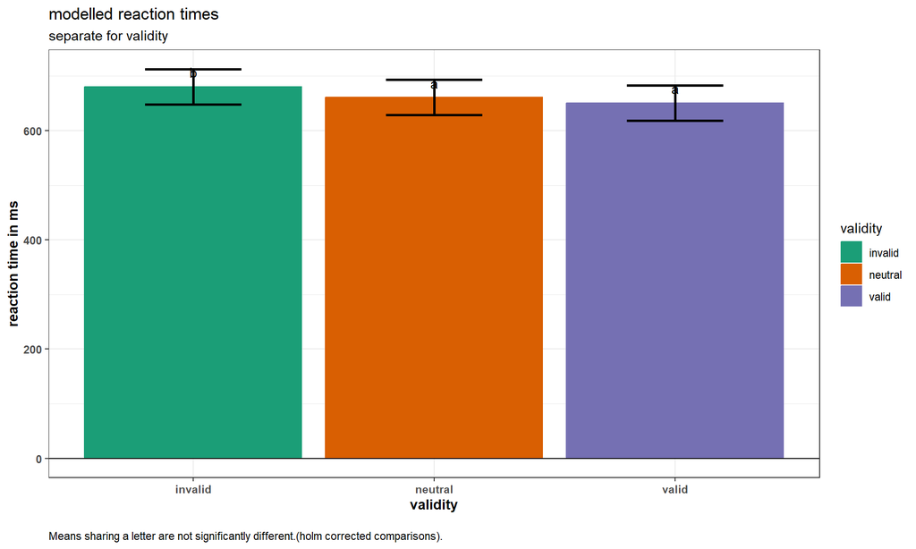

```r
CLD_obj = cld(anova_lsmeans_c,
          alpha=0.05,
          Letters=letters,      ### Use lower-case letters for .group
          adjust="holm")
CLD_obj$.group=gsub(" ", "", CLD_obj$.group)

ggplot(CLD_obj, aes(x = validity, y = lsmean, color = validity, fill = validity, label = .group)) +
  stat_summary(fun.data = mean_se, geom = "bar", position = "dodge") +
  geom_hline(yintercept=0, show.legend = FALSE) +
  geom_errorbar(aes(ymin = lower.CL, ymax = upper.CL), width=.4, size=.9, position = position_dodge(0.4),color = "black") +
  theme_bw() +
  theme(axis.title = element_text(face = "bold"), axis.text = element_text(face = "bold"),plot.caption = element_text(hjust = 0)) +
  ylab("reaction time in ms") +
  ggtitle("modelled reaction times",
           subtitle="separate for validity") +
  scale_x_discrete("validity") +
  labs(caption  = paste0("\nMeans sharing a letter are ",
                         "not significantly different.",
                         "(holm corrected comparisons)."), hjust=0.5) +
  geom_text(nudge_x = c(0, -0),
            nudge_y = c(26.7,  26.7),
            color   = "black")+
  scale_fill_brewer(palette = "Dark2")+
  scale_color_brewer(palette = "Dark2")
```

```r
## Seite
anova_lsmeans_c <- lsmeans(model2test, c("side"))
```

```
## NOTE: Results may be misleading due to involvement in interactions
```

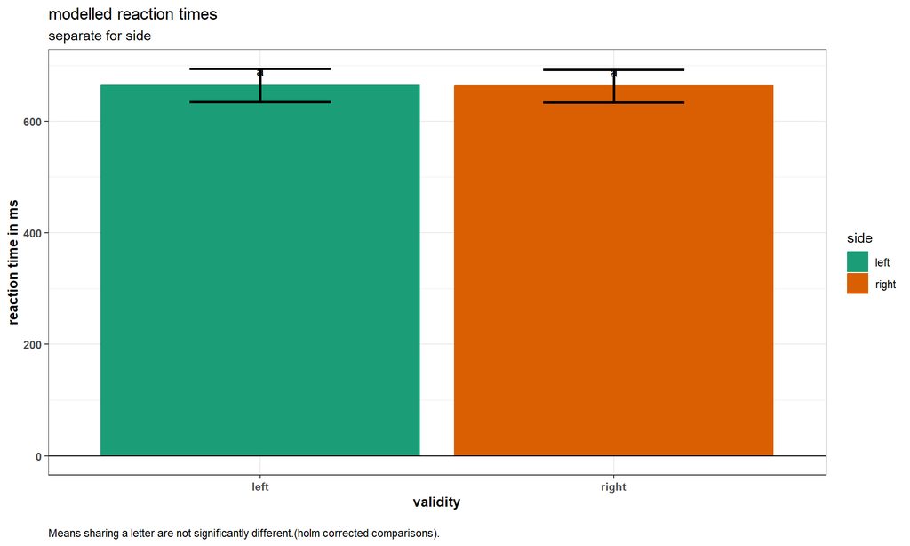

```r
CLD_obj = cld(anova_lsmeans_c,
          alpha=0.05,
          Letters=letters,      ### Use lower-case letters for .group
          adjust="holm")
CLD_obj$.group=gsub(" ", "", CLD_obj$.group)

ggplot(CLD_obj, aes(x = side, y = lsmean, color = side, fill = side, label = .group)) +
  stat_summary(fun.data = mean_se, geom = "bar", position = "dodge") +
  geom_hline(yintercept=0, show.legend = FALSE) +
  geom_errorbar(aes(ymin = lower.CL, ymax = upper.CL), width=.4, size=.9, position = position_dodge(0.4),color = "black") +
  theme_bw() +
  theme(axis.title = element_text(face = "bold"), axis.text = element_text(face = "bold"),plot.caption = element_text(hjust = 0)) +
  ylab("reaction time in ms") +
  ggtitle("modelled reaction times",
           subtitle="separate for side") +
  scale_x_discrete("validity") +
  labs(caption  = paste0("\nMeans sharing a letter are ",
                         "not significantly different.",
                         "(holm corrected comparisons)."), hjust=0.5) +
  geom_text(nudge_x = c(0, -0),
            nudge_y = c(26.7,  26.7),
            color   = "black")+
  scale_fill_brewer(palette = "Dark2")+
  scale_color_brewer(palette = "Dark2")
```

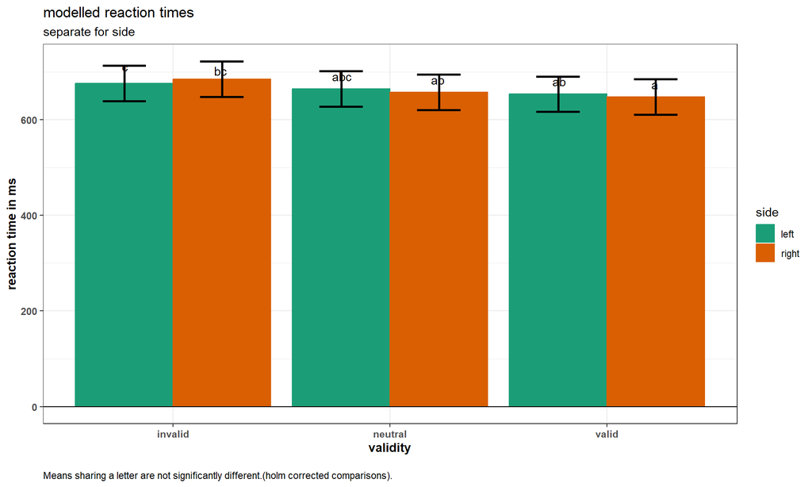

```r
## Validiaet X Seite
anova_lsmeans_c <- lsmeans(model2test, c("side","validity"))
CLD_obj = cld(anova_lsmeans_c,
          alpha=0.05,
          Letters=letters,      ### Use lower-case letters for .group
          adjust="holm")
CLD_obj$.group=gsub(" ", "", CLD_obj$.group)

ggplot(CLD_obj, aes(x = validity, y = lsmean, color = side, fill = side, label = .group)) +
  stat_summary(fun.data = mean_se, geom = "bar", position = "dodge") +
  geom_hline(yintercept=0, show.legend = FALSE) +
  geom_errorbar(aes(ymin = lower.CL, ymax = upper.CL), width=.4, size=.9, position = position_dodge(0.9),color = "black") +
  theme_bw() +
  theme(axis.title = element_text(face = "bold"), axis.text = element_text(face = "bold"),plot.caption = element_text(hjust = 0)) +
  ylab("reaction time in ms") +
  ggtitle("modelled reaction times",
           subtitle="separate for side") +
  scale_x_discrete("validity") +
  labs(caption  = paste0("\nMeans sharing a letter are ",
                         "not significantly different.",
                         "(holm corrected comparisons)."), hjust=0.5) +
  geom_text(nudge_x = c(0.22, -0.22, 0.22, -0.22),
            nudge_y = c(26.7,  26.7,26.7,  26.7),
            color   = "black")+
  scale_fill_brewer(palette = "Dark2")+
  scale_color_brewer(palette = "Dark2")
```

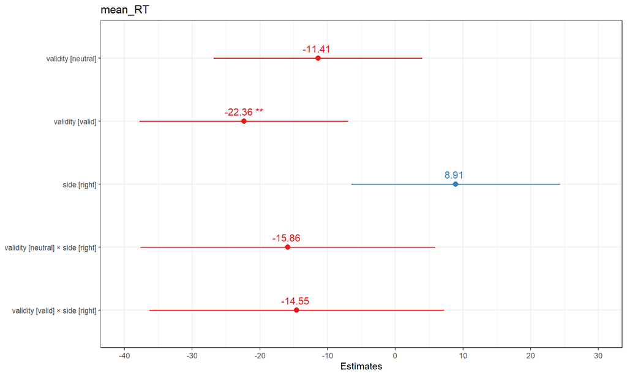

```r
plot_model(model2test, bpe.style = "dot",show.values = TRUE)
```

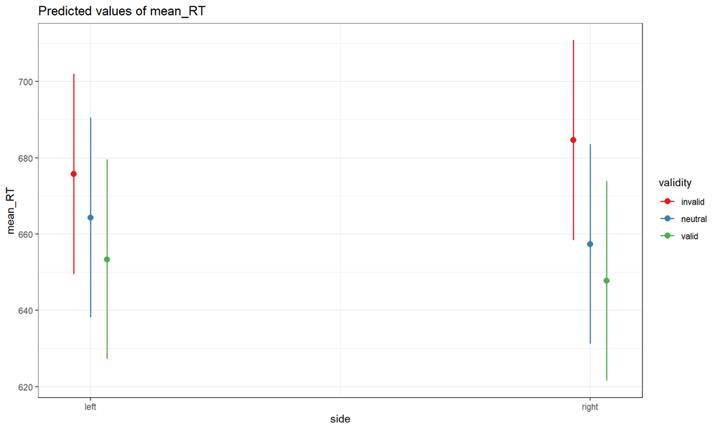

```r
plot_model(model2test, type = "pred", terms = c("side","validity"))
```

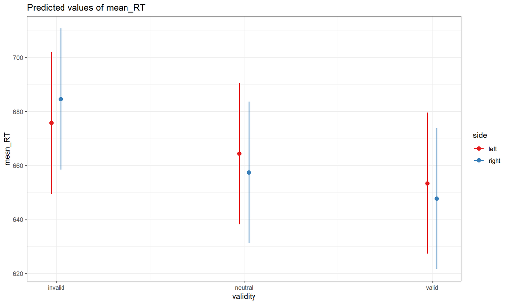

```r
plot_model(model2test, type = "pred", terms = c("validity","side"))
```

### linear mixed models RT II

1. **estimating model**

linear mixed model of standard effects based on single trial data

testing **reaction time ~ Validitaet * Seite + ( 1 | subjects)**

fixed effects | stepwise elimination

|  | eliminated factor | Eliminated | Sum Sq | Mean Sq | NumDF | DenDF | F value | Pr(>F) |
| --- | --- | --- | --- | --- | --- | --- | --- | --- |
| validity:side | validity:side | 0 | 150950 | 75474.8 | 2 | 16138.1 | 3.962 | 0.019 |

2. model description of best model
   - Best model is **lmerTest::lmer, post_RT ~ validity * side + (1 | subject), lmer_model_data2, TRUE**

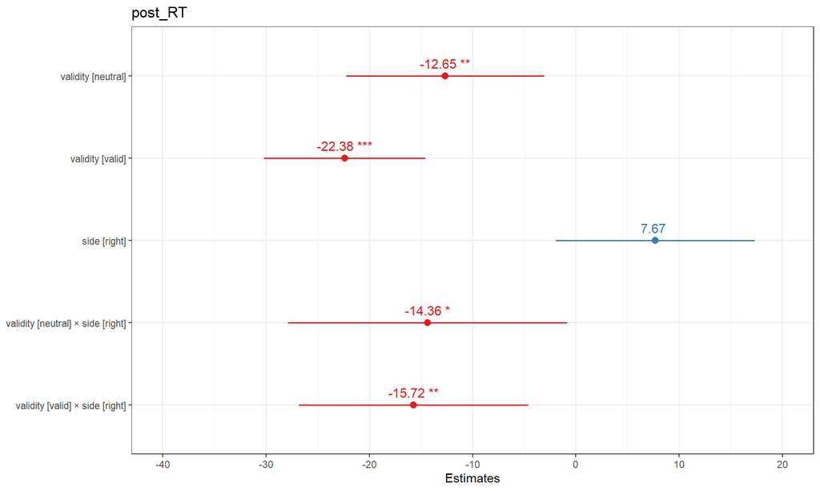

```r
model2test = best_model2

plot_model(model2test, bpe.style = "dot",show.values = TRUE)
```

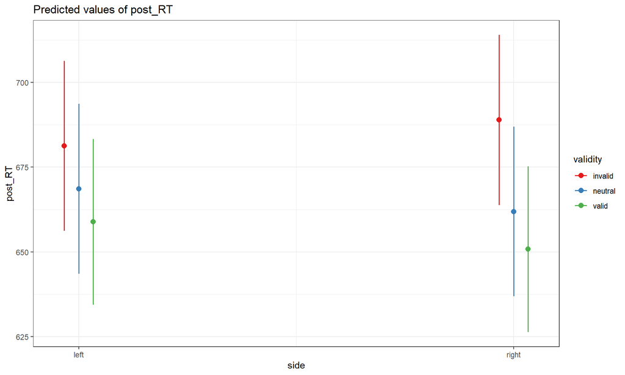

```r
plot_model(model2test, type = "pred", terms = c("side","validity"))
```

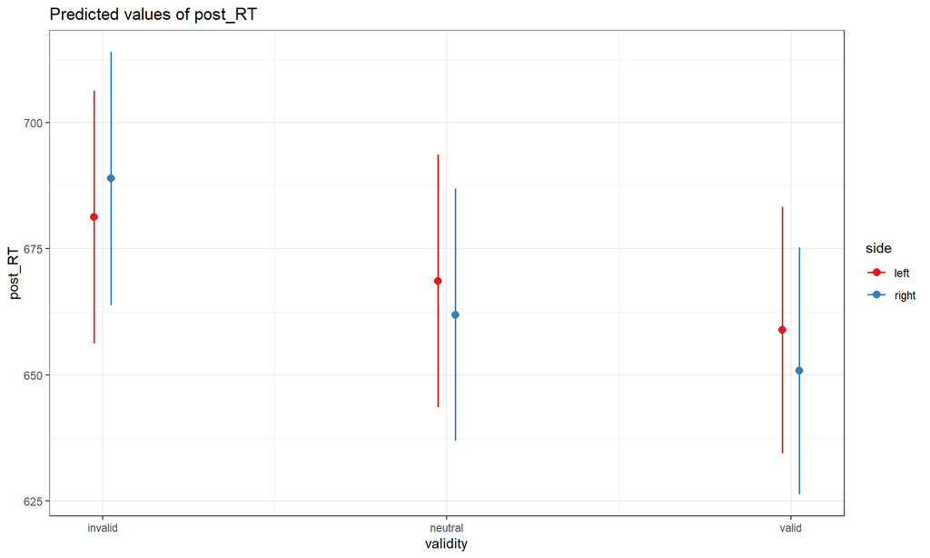

```r
plot_model(model2test, type = "pred", terms = c("validity","side"))
```

### linear mixed models RR

1. **estimating model**

linear mixed model of standard effects based on averaged data

testing **response rate ~ Validitaet * Seite + ( 1 | subjects)**

fixed effects | stepwise elimination

|  | eliminated factor | Eliminated | Sum Sq | Mean Sq | NumDF | DenDF | F value | Pr(>F) |
| --- | --- | --- | --- | --- | --- | --- | --- | --- |
| validity:side | validity:side | 1 | 7.744 | 3.872 | 2 | 135 | 0.099 | 0.9054 |
| side | side | 2 | 6.933 | 6.933 | 1 | 137 | 0.180 | 0.6717 |
| validity | validity | 0 | 593.013 | 296.507 | 2 | 138 | 7.762 | < .001 |

2. model description of best model
   - Best model is lmerTest::lmer, rate_perc ~ validity + (1 | subject), lmer_model_data, TRUE

```r
model2test = best_model
model2test = model_valXside

## validity
anova_lsmeans_c <- lsmeans(model2test, c("validity"))
```

```
## NOTE: Results may be misleading due to involvement in interactions
```

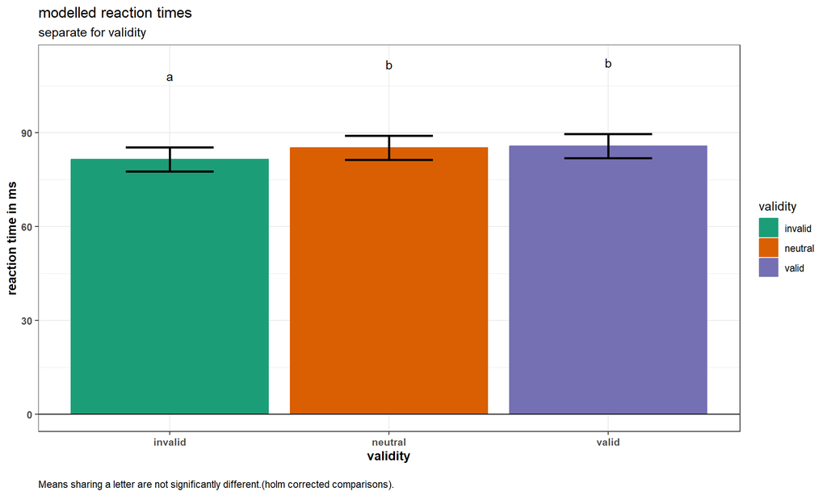

```r
CLD_obj = cld(anova_lsmeans_c,
          alpha=0.05,
          Letters=letters,      ### Use lower-case letters for .group
          adjust="holm")
CLD_obj$.group=gsub(" ", "", CLD_obj$.group)

ggplot(CLD_obj, aes(x = validity, y = lsmean, color = validity, fill = validity, label = .group)) +
  stat_summary(fun.data = mean_se, geom = "bar", position = "dodge") +
  geom_hline(yintercept=0, show.legend = FALSE) +
  geom_errorbar(aes(ymin = lower.CL, ymax = upper.CL), width=.4, size=.9, position = position_dodge(0.4),color = "black") +
  theme_bw() +
  theme(axis.title = element_text(face = "bold"), axis.text = element_text(face = "bold"),plot.caption = element_text(hjust = 0)) +
  ylab("reaction time in ms") +
  ggtitle("modelled reaction times",
           subtitle="separate for validity") +
  scale_x_discrete("validity") +
  labs(caption  = paste0("\nMeans sharing a letter are ",
                         "not significantly different.",
                         "(holm corrected comparisons)."), hjust=0.5) +
  geom_text(nudge_x = c(0, -0),
            nudge_y = c(26.7,  26.7),
            color   = "black")+
  scale_fill_brewer(palette = "Dark2")+
  scale_color_brewer(palette = "Dark2")
```

```r
## Seite
anova_lsmeans_c <- lsmeans(model2test, c("side"))
```

```
## NOTE: Results may be misleading due to involvement in interactions
```

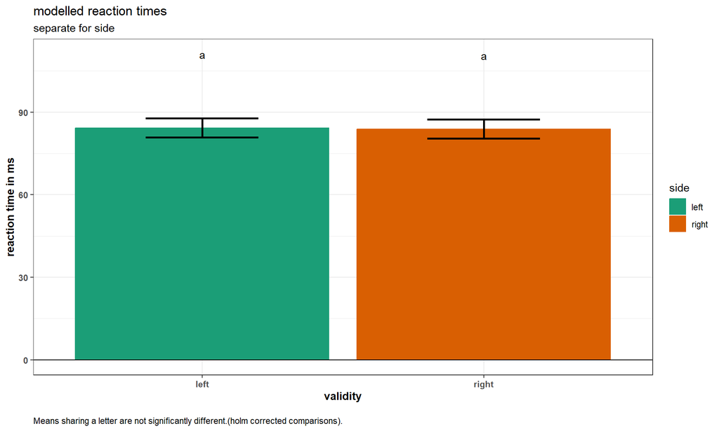

```r
CLD_obj = cld(anova_lsmeans_c,
          alpha=0.05,
          Letters=letters,      ### Use lower-case letters for .group
          adjust="holm")
CLD_obj$.group=gsub(" ", "", CLD_obj$.group)

ggplot(CLD_obj, aes(x = side, y = lsmean, color = side, fill = side, label = .group)) +
  stat_summary(fun.data = mean_se, geom = "bar", position = "dodge") +
  geom_hline(yintercept=0, show.legend = FALSE) +
  geom_errorbar(aes(ymin = lower.CL, ymax = upper.CL), width=.4, size=.9, position = position_dodge(0.4),color = "black") +
  theme_bw() +
  theme(axis.title = element_text(face = "bold"), axis.text = element_text(face = "bold"),plot.caption = element_text(hjust = 0)) +
  ylab("reaction time in ms") +
  ggtitle("modelled reaction times",
           subtitle="separate for side") +
  scale_x_discrete("validity") +
  labs(caption  = paste0("\nMeans sharing a letter are ",
                         "not significantly different.",
                         "(holm corrected comparisons)."), hjust=0.5) +
  geom_text(nudge_x = c(0, -0),
            nudge_y = c(26.7,  26.7),
            color   = "black")+
  scale_fill_brewer(palette = "Dark2")+
  scale_color_brewer(palette = "Dark2")
```

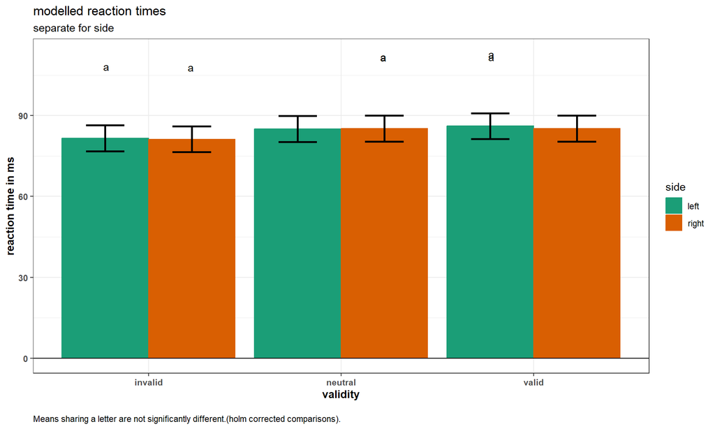

```r
## Validiaet X Seite
anova_lsmeans_c <- lsmeans(model2test, c("side","validity"))
CLD_obj = cld(anova_lsmeans_c,
          alpha=0.05,
          Letters=letters,      ### Use lower-case letters for .group
          adjust="holm")
CLD_obj$.group=gsub(" ", "", CLD_obj$.group)

ggplot(CLD_obj, aes(x = validity, y = lsmean, color = side, fill = side, label = .group)) +
  stat_summary(fun.data = mean_se, geom = "bar", position = "dodge") +
  geom_hline(yintercept=0, show.legend = FALSE) +
  geom_errorbar(aes(ymin = lower.CL, ymax = upper.CL), width=.4, size=.9, position = position_dodge(0.9),color = "black") +
  theme_bw() +
  theme(axis.title = element_text(face = "bold"), axis.text = element_text(face = "bold"),plot.caption = element_text(hjust = 0)) +
  ylab("reaction time in ms") +
  ggtitle("modelled reaction times",
           subtitle="separate for side") +
  scale_x_discrete("validity") +
  labs(caption  = paste0("\nMeans sharing a letter are ",
                         "not significantly different.",
                         "(holm corrected comparisons)."), hjust=0.5) +
  geom_text(nudge_x = c(0.22, -0.22, 0.22, -0.22),
            nudge_y = c(26.7,  26.7,26.7,  26.7),
            color   = "black")+
  scale_fill_brewer(palette = "Dark2")+
  scale_color_brewer(palette = "Dark2")
```

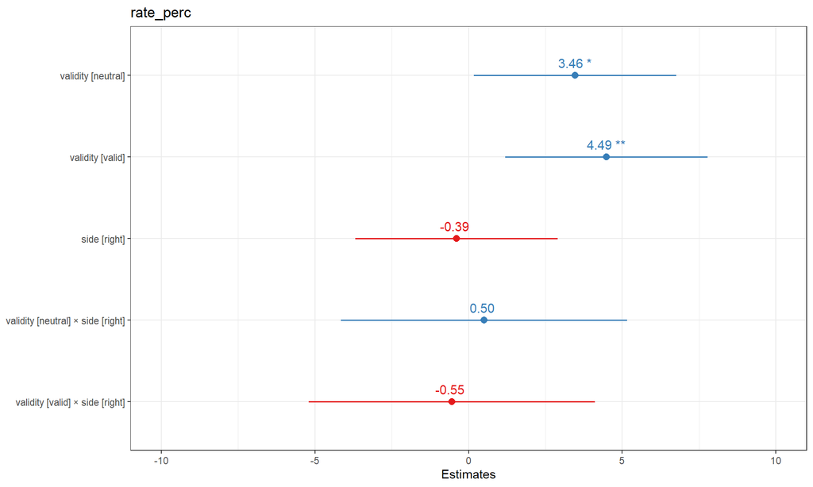

```r
plot_model(model2test, bpe.style = "dot",show.values = TRUE)
```

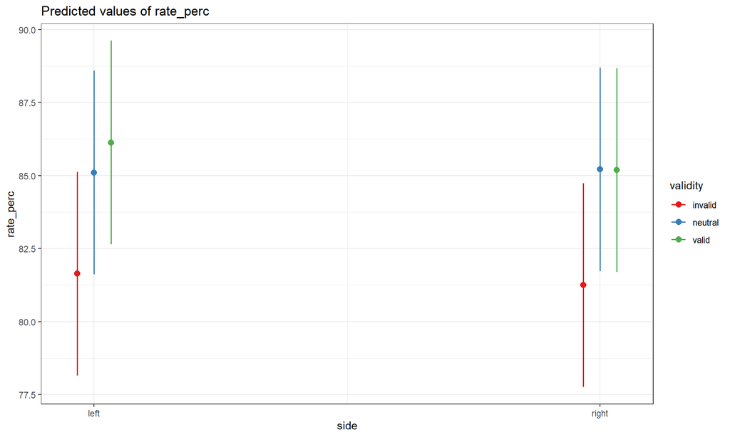

```r
plot_model(model2test, type = "pred", terms = c("side","validity"))
```

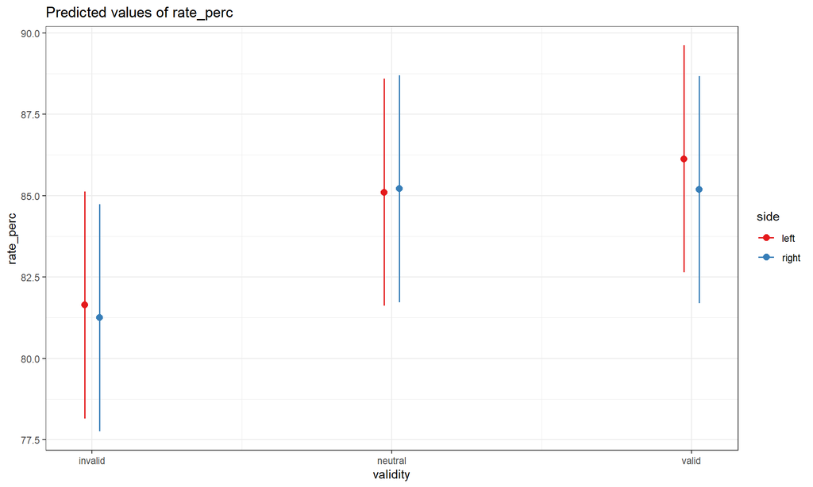

```r
plot_model(model2test, type = "pred", terms = c("validity","side"))
```

### linear mixed models RR II

1. **estimating model**

linear mixed model of standard effects based on single trial data

fixed effects | stepwise elimination

|  | eliminated factor | Eliminated | Sum Sq | Mean Sq | NumDF | DenDF | F value | Pr(>F) |
| --- | --- | --- | --- | --- | --- | --- | --- | --- |
| validity:side | validity:side | 1 | 0.080 | 0.040 | 2 | 17775 | 0.322 | 0.7248 |
| side | side | 2 | 0.170 | 0.170 | 1 | 17777 | 1.369 | 0.242 |
| validity | validity | 0 | 4.847 | 2.424 | 2 | 17778 | 19.533 | < .001 |

2. model description of best model
   - Best model is **lmerTest::lmer, post_hit ~ validity + (1 | subject), lmer_model_data2, TRUE**

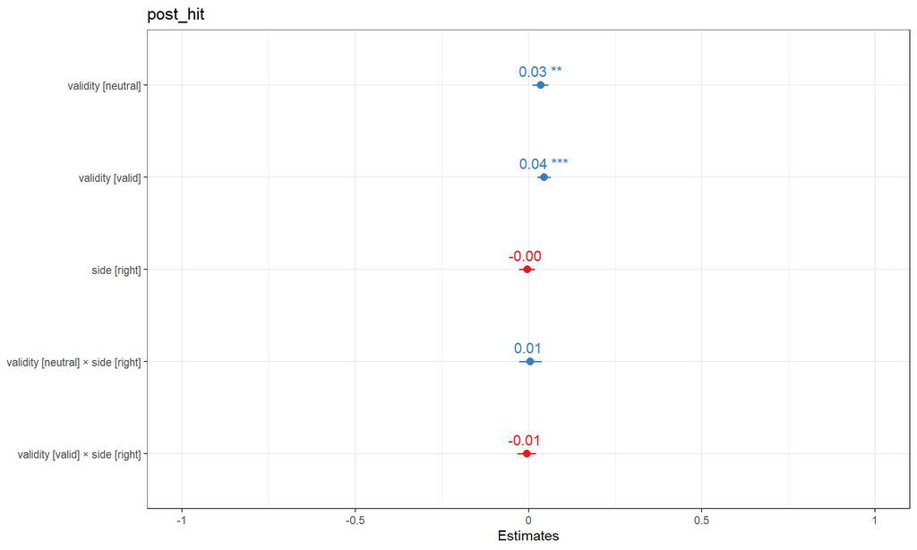

```r
model2test = best_model2
model2test = model2_valXside

plot_model(model2test, bpe.style = "dot",show.values = TRUE)
```

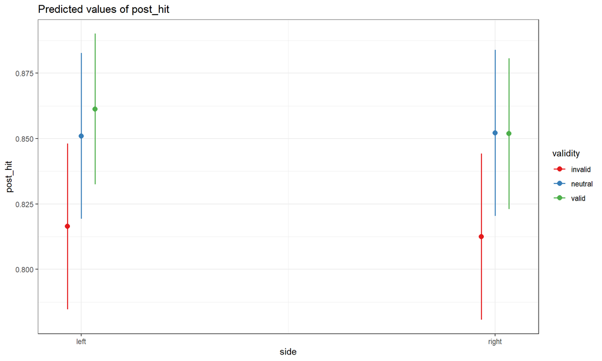

```r
plot_model(model2test, type = "pred", terms = c("side","validity"))
```

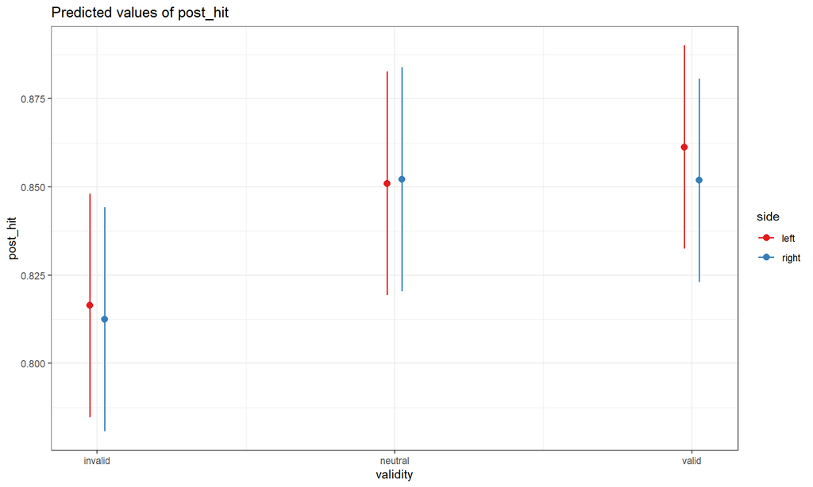

```r
plot_model(model2test, type = "pred", terms = c("validity","side"))
```